# fifth assignment Travaglini

Simone Travaglini

2023-11-03

*PART ONE:*

```r
#import dataset for the training part
x <- read.csv("uk_train.csv", stringsAsFactors=FALSE)
#display the training dataset
str(x)
x$polite <- factor(x$polite, levels= c("polite", "impolite"), labels=c("polite", "impolite"))
is.factor(x$polite)#yes

table(x$polite) #256 and 104
prop.table(table(x$polite))#0.71 and 0.29
nrow(x)#360

traincorpus <- corpus(x)
tok <- tokens(traincorpus , remove_punct = TRUE, remove_numbers=TRUE, remove_symbols = TRUE, split_hyphens = TRUE, remove_separators = TRUE, remove_url = TRUE)
tok <- tokens_remove(tok, stopwords("en"))
# let's also remove the unicode symbols
tok <- tokens_remove(tok, c("@*"))
tok <- tokens_remove(tok, c("#*"))
tok <- tokens_wordstem (tok)
Dfm_train <- dfm(tok)

# Let's trim the dfm using min_doqfreq=2
Dfm_train <- dfm_trim(Dfm_train , min_docfreq = 2, verbose=TRUE)
Dfm_train  <- dfm_remove(Dfm_train , min_nchar = 2)
```

By using the code here above, I started by loading data from a CSV file called ‘uk_train.csv’ and transformed this data into a ‘data.frame’ object called x. I had to treat the variable ‘polite’ as a factor with two labels, ‘polite’ and ‘impolite’.

Next, I created a corpus based on the data in my training ‘data.frame’. Text tokenization was an important step in which I removed punctuation, numbers, symbols, hyphens, separators and URLs. I also removed common English words (stopwords) and managed the removal of unicode symbols. To simplify the process, I performed word stemming, which reduces the different forms of the same words to a basic form.

Next, I applied DfM reduction to keep only words with a minimum frequency in the documents (using ‘min_docfreq=2’) and removed words with less than 2 characters. Finally, I identified and presented the 20 most common features within my training set.

```r
# display the top 20 features
topfeatures(Dfm_train , 20)
```

```
##    ukip     get   peopl     amp     can    look    like    time    fffd     one
##      24      22      16      16      15      15      14      14      14      13
##    just    good english     now   think   thank      go   parti   right    make
##      13      12      11      11      11      11      11      11      11      10
```

```r
xtest <- read.csv("uk_test2.csv", stringsAsFactors=FALSE)
str(xtest)
#in this dataset, the variables polite and sentiment are empty
nrow(xtest)

testcorpus <- corpus(xtest)
tok2 <- tokens(testcorpus , remove_punct = TRUE, remove_numbers=TRUE, remove_symbols = TRUE, split_hyphens = TRUE, remove_separators = TRUE, remove_url = TRUE)
tok2 <- tokens_remove(tok2, stopwords("en"))
# let's also remove the unicode symbols
tok2 <- tokens_remove(tok2, c("@*"))
tok2 <- tokens_remove(tok2, c("#*"))
tok2 <- tokens_wordstem (tok2)
Dfm_test <- dfm(tok2)

# Let's trim the dfm using min_doqfreq=2
Dfm_test <- dfm_trim(Dfm_test , min_docfreq = 2, verbose=TRUE)
Dfm_test  <- dfm_remove(Dfm_test , min_nchar = 2)
topfeatures(Dfm_test, 20)

Dfm_test[ntoken(Dfm_test) != 0,] #343 documents
Dfm_test[ntoken(Dfm_test) == 0, ] #17 documents
#let's remove all the empty documents
Dfm_test <- Dfm_test[ntoken(Dfm_test) != 0,]
#let's check
Dfm_test[ntoken(Dfm_test) == 0,]#no empty documents
```

Next, I tackled the test set. I loaded the data from a CSV file called ‘uk_test2.csv’ and transformed it into another ‘data.frame’ object called xtest. I performed similar operations as in the first step, creating a corpus from the data in my test ‘data.frame’ and applying tokenization, stopword removal, unicode symbol handling and word stemming. Next, I created a DfM for the test set, reducing the DfM with the same ‘min_docfreq=2’ parameter and removing terms with less than 2 characters. I also highlighted the 20 most common features in the test set.

```r
# display the top 20 features
topfeatures(Dfm_test, 20)
```

```
##    amp   ukip   vote  thank   make   need  peopl  parti  think   fuck    can
##     26     22     20     20     19     17     17     15     15     15     14
##   like   just    one    say racist   know    get     go  polit
##     14     14     13     12     12     11     11     11     11
```

```r
setequal(featnames(Dfm_train), featnames(Dfm_test))#false
nfeat(Dfm_test)#407
nfeat(Dfm_train)#414

test_dfm  <- dfm_match(Dfm_test, features = featnames(Dfm_train))
nfeat(test_dfm)
setequal(featnames(Dfm_train), featnames(test_dfm))

xtotal <- rbind(x, xtest)
str(xtotal)

corpustrain3 <- corpus(xtotal)
tok3 <- tokens(corpustrain3, remove_punct = TRUE, remove_numbers=TRUE, remove_symbols = TRUE, split_hyphens = TRUE, remove_separators = TRUE, remove_url = TRUE)
tok3 <- tokens_remove(tok3, stopwords("en"))
# let's also remove the symbols
tok3 <- tokens_remove(tok3, c("0*"))
tok3 <- tokens_remove(tok3, c("#*"))
tok3 <- tokens_remove(tok3, c("@*"))
tok3 <- tokens_wordstem (tok3)
dfm_tot <- dfm(tok3)
dfm_tot <- dfm_trim(dfm_tot , min_docfreq = 2, verbose=TRUE)
dfm_tot <- dfm_remove(dfm_tot , min_nchar = 2)
ndoc(dfm_tot)
```

```r
#display the top 20 features
topfeatures(dfm_tot, 20)
```

```
##  ukip   amp   get peopl thank   can  vote  make  like  just   one think parti
##    46    42    33    33    31    29    29    29    28    27    26    26    26
##  fuck  time  fffd  need  good    go  look
##    25    24    24    23    22    22    22
```

```r
# let's now separate the texts

train_dfm_alt <- dfm_subset(dfm_tot,!is.na(polite))
train_dfm_alt

test_dfm_alt <- dfm_subset(dfm_tot,is.na(polite))
test_dfm_alt

setequal(featnames(train_dfm_alt), featnames(test_dfm_alt)) #true
```

Finally, I had to make the features between the training set and the test set identical. I combined the data from the two sets into a single data structure called xtotal. Once again, I created a corpus based on this data and applied tokenization, removing punctuation, numbers, symbols, hyphens, separators, URLs and stopwords, as well as handling the removal of unicode symbols and word stemming.

I then created a DfM based on this corpus and applied DfM reduction with the same ‘min_docfreq=2’ parameter, together with the removal of terms with less than 2 characters. Finally, I separated the data according to the variable ‘polite’, ensuring that the training set and the test set had the same number of features.

```r
# dense matrix
train_dm <- as.matrix(Dfm_train)
object.size(train_dm) # 1242848 bytes

# compressed matrix
train <- as(Dfm_train, "dgCMatrix")
object.size(train) #70544 bytes

object.size(train_dm)/object.size(train) #17.6 bytes
# large difference among those 2 matrix

test <- as(test_dfm, "dgCMatrix")
```

In the next part of my script, I compared a dense matrix with a compressed matrix.

I started by converting my training DfM into a dense matrix using as.matrix(Dfm_train), and calculated the size in memory of this dense matrix with object.size(train_dm). The resulting size was 1,242,848 bytes, which represents a large amount of memory.

Next, I converted the training DfM into a compressed matrix using as(Dfm_train, “dgCMatrix”). The memory size of this compressed matrix was calculated with object.size(train), resulting in 70,544 bytes.

Finally, I calculated the ratio between the sizes of the two matrices with object.size(train_dm)/object.size(train), resulting in a value of 17.6. This value indicates that the dense matrix occupies approximately 17.6 times more memory than the compressed matrix.

*SECOND STEP: NAIVE BAYES MODEL*

Script for my naive bayes model:

```r
table(Dfm_train@x)
#    1    2    4    6
# 1377   37    2    1

#dv
str(Dfm_train@docvars$polite) #it is a factor

# naive bayes model
system.time(naive_b_model <- multinomial_naive_bayes(x=train, y=Dfm_train@docvars$polite))
```

In the next part of my script, I performed a more detailed analysis of the data and created a Naive Bayes classification model to predict the ‘polite’ or ‘impolite’ class of documents based on the training DfM. Next, I created a Naive Bayes classification model using the multinomial_naive_bayes function. I trained the model using the compressed matrix called “train” as the independent variable and the values of the variable ‘polite’ from the training data as the dependent variable. The resulting Naive Bayes model was stored in the variable naive_b_model.

```r
naive_b_model
```

```
##
## ============================ Multinomial Naive Bayes ============================
##
##  Call:
## multinomial_naive_bayes(x = train, y = Dfm_train@docvars$polite)
##
## ---------------------------------------------------------------------------------
##
## Laplace smoothing: 0.5
##
## ---------------------------------------------------------------------------------
##
##  A priori probabilities:
##    polite  impolite
## 0.7111111 0.2888889
##
## ---------------------------------------------------------------------------------
##
##           Classes
## Features        polite     impolite
##   faith    0.002832861 0.0007955449
##   reform   0.002832861 0.0007955449
##   oppos    0.002023472 0.0007955449
##   gay      0.006070417 0.0023866348
##   marriag  0.006879806 0.0007955449
##   english  0.005261028 0.0087509944
##   scotland 0.002023472 0.0039777247
##   get      0.013354917 0.0103420843
##   one      0.009307972 0.0039777247
##   agre     0.003642250 0.0007955449
##
## ---------------------------------------------------------------------------------
##
## # ... and 395 more features
##
## ---------------------------------------------------------------------------------
```

*explanation of output*

A priori probability:

The class ‘polite’ has an a priori probability of 0.7111111. The class “impolite” has an a priori probability of 0.2888889.

Then, I also calculated and showed the first 10 most indicative words for the class ‘impolite’ and the first 10 most indicative words for the class ‘polite’ using the lines of code here below:

```r
# for the "impolite" label?
head(sort((naive_b_model$params[,2]-naive_b_model$params[,1]) , decreasing=TRUE), 10)
```

```
##        fuck        fffd      stupid         use      racist        twat
## 0.016301749 0.013064194 0.008346300 0.008346300 0.008318612 0.006755210
##     everyon        must       speak       enjoy
## 0.006727522 0.006699834 0.005164120 0.005164120
```

```r
# and for the "polite" label?
head(sort((naive_b_model$params[,1]-naive_b_model$params[,2]) , decreasing=TRUE), 10)
```

```
##        good        time       peopl       thank     marriag        know
## 0.009321816 0.008540115 0.007758414 0.006111949 0.006084261 0.006084261
##         one         new        word        need
## 0.005330248 0.005274872 0.005274872 0.004465483
```

The output shows the difference between the conditional probabilities of each word for the “impolite” class and the “polite” class.

*impolite*

The top 10 words with the highest differences that are more indicative of the “impolite” class are: “fuck” “fffd” “stupid” “use” “racist” “twat” and so on. These words are more likely to be associated with impolite language or content so far.

*polite*

The top 10 words with the highest differences that are more indicative of the “polite” class are: “good” “time” “people” “thank” “marriage” “known”, etc.

*Testing the model*

Then, I proceeded to make predictions on the test set using the Naive Bayes classification model that I had previously trained. Here’s what I did:

```r
# let's predict the test-set
predicted_nb <- predict(naive_b_model ,test)
```

I used the trained Naive Bayes model, stored in the “naive_b_model” variable, to predict the classes of documents in the test set. The predictions were assigned to the variable “predicted_nb.”

I displayed the frequency of these predictions using table(predicted_nb), which provided a count of how many documents were classified into each class. Additionally, I showed the proportions of these predictions using prop.table(table(predicted_nb)).

```r
table(predicted_nb)
```

```
## predicted_nb
##   polite impolite
##      279       64
```

```r
prop.table(table(predicted_nb))
```

```
## predicted_nb
##    polite  impolite
## 0.8134111 0.1865889
```

In the test dataset, the 81% of text are polite, while just the 19% of them are impolite.

I also demonstrated how to extract and view these probabilities for each class using head(predict(naive_b_model, test, type=“prob”)).

```r
head(predict(naive_b_model ,test), 25)
```

```
##  [1] polite   polite   polite   polite   polite   polite   polite   polite
##  [9] polite   polite   polite   polite   polite   polite   polite   polite
## [17] polite   polite   polite   polite   polite   polite   impolite polite
## [25] polite
## Levels: polite impolite
```

```r
head(predict(naive_b_model, test, type="prob"), 25)
```

```
##           polite    impolite
## text2  0.7111111 0.288888889
## text3  0.7140696 0.285930422
## text4  0.9494510 0.050548953
## text5  0.6940265 0.305973488
## text6  0.9865139 0.013486095
## text7  0.9393573 0.060642661
## text8  0.8975967 0.102403320
## text9  0.8211524 0.178847621
## text10 0.7111111 0.288888889
## text11 0.9683882 0.031611783
## text12 0.9736698 0.026330180
## text13 0.9562157 0.043784322
## text14 0.8729068 0.127093212
## text15 0.9986453 0.001354677
## text16 0.6622559 0.337744131
## text17 0.9885049 0.011495116
## text18 0.6439652 0.356034773
## text19 0.8975967 0.102403320
## text20 0.8975967 0.102403320
## text21 0.8622767 0.137723319
## text22 0.9960226 0.003977352
## text23 0.7767008 0.223299171
## text24 0.0838041 0.916195898
## text25 0.8975967 0.102403320
## text26 0.8769612 0.123038820
```

*THIRD STEP: RANDOM FOREST*

I first created the random forest model using the ranger function and using the data contained in the train matrix.

```r
set.seed(123)
system.time(RF <- ranger(y= Dfm_train@docvars$polite, x=train, keep.inbag=TRUE))
```

```r
RF
```

```
## Ranger result
##
## Call:
##  ranger(y = Dfm_train@docvars$polite, x = train, keep.inbag = TRUE)
##
## Type:                             Classification
## Number of trees:                  500
## Sample size:                      360
## Number of independent variables:  405
## Mtry:                             20
## Target node size:                 1
## Variable importance mode:         none
## Splitrule:                        gini
## OOB prediction error:             25.28 %
```

```r
RF$inbag.counts[1]
```

```
## [[1]]
##   [1] 1 1 0 2 0 0 3 0 0 2 3 0 5 0 2 0 0 0 2 0 0 1 2 0 0 1 2 1 0 1 1 1 1 1 0 1 1
##  [38] 1 0 0 0 2 3 1 1 2 0 1 0 0 1 1 2 2 1 2 1 0 1 2 1 0 1 0 0 0 2 2 1 1 2 2 3 0
##  [75] 3 0 1 4 0 1 1 0 1 0 1 0 1 2 0 1 0 2 1 2 0 1 2 1 2 0 2 1 0 1 3 1 0 0 1 0 1
## [112] 1 1 0 2 1 2 0 1 1 0 1 1 1 2 2 2 1 2 2 0 0 0 1 1 1 1 1 3 2 0 1 1 1 1 3 1 1
## [149] 3 0 0 1 1 0 3 0 0 2 2 1 2 1 2 1 1 0 1 2 0 0 0 0 0 1 0 0 0 0 2 1 0 0 0 2 0
## [186] 1 1 1 2 1 0 3 1 4 0 1 1 0 1 1 1 2 0 0 2 0 2 2 3 1 0 0 1 2 2 0 0 2 2 2 1 0
## [223] 1 0 3 2 3 0 1 0 0 2 1 2 0 0 2 1 2 0 0 1 1 1 1 1 0 1 0 0 1 0 0 1 1 1 2 2 3
## [260] 1 1 1 1 0 2 2 0 1 0 2 1 1 0 0 1 1 1 0 1 1 1 0 1 0 2 0 0 0 1 0 1 2 2 1 1 0
## [297] 0 1 3 0 1 2 2 1 3 2 2 1 0 0 1 0 1 0 0 2 1 2 2 0 2 0 1 1 0 0 1 2 2 0 1 1 3
## [334] 1 1 2 1 0 0 0 2 2 1 2 0 3 1 0 0 1 0 1 1 1 0 2 0 2 2 1
```

For the first tree, the first text appears once as well as the second. the third does not appear while the fourth appears twice.

```r
1-RF$prediction.error#0.7416667
```

```
## [1] 0.7472222
```

Since 500 was the default number of trees, I wanted to use this function to see what was the number of trees with the lowest oob error. I set the loop to see it in an interval between 1 dawn up to 501.

```r
nt <- seq(1, 501, 10)
nt

oob_mse <- vector("numeric", length(nt))

for(i in 1:length(nt)){
  set.seed(123)
  rr2 <- ranger(y= Dfm_train@docvars$polite, x=train,  num.threads=4, num.trees = nt[i], write.forest = FALSE)
  oob_mse[i] <- rr2$prediction.error
}
```

And then the plot:

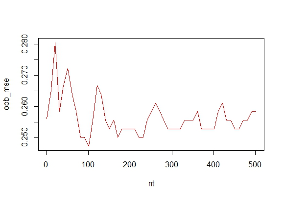

```r
plot(x = nt, y = oob_mse, col = "red", type = "l")
```

It would seem that the optimal number of trees is 101. Said this I tried to set a new model with the best number of trees according to this data:

```r
set.seed(123)
system.time(rf2 <- ranger(y= Dfm_train@docvars$polite, num.trees = 100, x=train, keep.inbag=TRUE))
```

```r
rf2
```

```
## Ranger result
##
## Call:
##  ranger(y = Dfm_train@docvars$polite, num.trees = 100, x = train,      keep.inbag = TRUE)
##
## Type:                             Classification
## Number of trees:                  100
## Sample size:                      360
## Number of independent variables:  405
## Mtry:                             20
## Target node size:                 1
## Variable importance mode:         none
## Splitrule:                        gini
## OOB prediction error:             26.11 %
```

After it, i create another model called RFI, calculating the variable importance using permutation:

```r
set.seed(123)
system.time(RFI <- ranger(y= Dfm_train@docvars$polite, x=train, num.trees = 100, importance="permutation", scale.permutation.importance = TRUE))
```

```r
# 10 most important words
head(sort(RFI$variable.importance , decreasing=TRUE), 10)
```

```
##     fuck   stupid     twat   bloodi      ars    idiot     noth   sicken
## 37.18699 18.21547 16.43762 14.44783 10.96045 10.80743 10.48118 10.43476
##      lol      use
## 10.23676 10.07474
```

Then, I proceeded to predict the classes of documents in the test set using the Random Forest model rf2 (the second one, with 100 numbers of trees). I ensured consistent results by setting the random seed again with set.seed(123). I used the predict function on the Random Forest model and stored the predictions in the “predicted_rf” variable.

```r
set.seed(123)
system.time(predicted_rf <- predict(rf2, test))
```

I examined the frequency of class predictions using the script here below:

```r
table(predicted_rf$predictions )#polite 296 impolite 47
```

```
##
##   polite impolite
##      305       38
```

```r
prop.table(table(predicted_rf$predictions ))#polite 0.8629738  impolite 0.1370262
```

```
##
##    polite  impolite
## 0.8892128 0.1107872
```

Lastly, I set the argument “predict.all=TRUE,” in order to access the predictions made by each tree for specific documents in the test set.

```r
set.seed(123)
system.time(predicted_rfALL <- predict(rf2, test, predict.all=TRUE))
str(predicted_rfALL )
```

for example, here i displayed the prediction of heach trees for the document number 5:

```r
predicted_rfALL$predictions[5,]
```

```
##   [1] 1 2 2 2 2 1 1 2 2 1 1 1 1 2 1 1 2 1 1 1 2 1 1 2 2 2 1 1 1 2 1 1 2 2 1 2 2
##  [38] 2 2 2 2 1 1 1 1 2 2 2 2 2 2 2 2 1 2 1 2 1 2 1 1 1 1 2 2 1 2 2 1 2 2 2 1 2
##  [75] 1 1 2 1 1 2 2 2 2 2 2 2 2 1 2 2 1 2 1 2 2 2 2 2 2 2
```

As can be seen, the majority of the trees classifies this document as 2 = impolite

*FOURTH STEP: SUPPORT VECTOR MACHINE*

The last part was about the Support vector machine model.

```r
system.time(SV <- svm(y= Dfm_train@docvars$polite, x=train, kernel='linear'))
```

```r
length(SV$index)
```

```
## [1] 243
```

Then, I looked into the coefficients for the support vectors, which represent the weights for determining the location of the decision boundary

```r
head(SV$coefs)
```

```
##             [,1]
## [1,] 0.223024858
## [2,] 0.007444717
## [3,] 0.119130647
## [4,] 1.000000000
## [5,] 0.927286879
## [6,] 1.000000000
```

I examined the decision values used for classifying the documents in the training set. In this context, positive coefficients indicated “Polite” while negative coefficients indicated “Impolite”. I displayed the decision values for the first few documents using “head(SV$decision.values)” and made class predictions for the training data with “head(predict(SV, train))”

```r
head(SV$decision.values)
```

```
##   polite/impolite
## 1       1.3955311
## 2       1.0002885
## 3       1.3210622
## 4       1.0000211
## 5       0.9998104
## 6       0.8806797
```

```r
head(predict(SV , train))
```

```
##      1      2      3      4      5      6
## polite polite polite polite polite polite
## Levels: polite impolite
```

As shown in the output here above, all the first 5 documents are classified as polite.

```r
vectors <- x[SV$index,]
nrow(vectors)
str(vectors)
vectors$coefs <- SV$coefs[,1]
str(vectors)
summary(vectors$coefs)
```

```r
str(vectors)
```

```
## 'data.frame':    243 obs. of  7 variables:
##  $ X          : int  6 8 9 11 22 31 36 47 54 81 ...
##  $ id         : num  4.71e+17 4.71e+17 4.71e+17 4.71e+17 4.71e+17 ...
##  $ screen_name: chr  "GawainTowler" "camsquirrel" "GoodallGiles" "BobbinsonCrusoe" ...
##  $ text       : chr  "@craigmelson not funny..." ".@StanCollymore I'll put a weighty Griffin on my sleigh as I inveigh against fascists...     @YsabelleStewart @nickgriffinmep" "@pswidlicki @GrillingKippers Couldn't be worse now could it?" "@tangowhisky26 @Tim_Aker @UKIP @Nigel_Farage @Ed_Miliban…
##  $ polite     : Factor w/ 2 levels "polite","impolite": 1 1 1 1 1 1 1 1 1 1 ...
##  $ Sentiment  : chr  "negative" "neutral" "negative" "neutral" ...
##  $ coefs      : num  1 1 1 1 1 1 1 1 1 1 ...
```

Using this function we can see that texts 1 2 3 4 5, 7 and 10 are not included because they are not supporting vectors.

After it, I decided to display the first texts with a negative coefficient(impolite):

```r
# impolite texts (negative coefficient)
vectors1<- vectors[order(vectors$coef),]
str(vectors)

strwrap((vectors1$text)[1:5])
```

[output not shown]

… And the firsts text with a positive coefficient(polite):

```r
# polite texts (positive coefficient)
vectors2 <- vectors[order(-vectors$coef),]
str(vectors2)
```

```
## 'data.frame':    243 obs. of  7 variables:
##  $ X          : int  6 8 9 11 22 31 36 47 54 81 ...
##  $ id         : num  4.71e+17 4.71e+17 4.71e+17 4.71e+17 4.71e+17 ...
##  $ screen_name: chr  "GawainTowler" "camsquirrel" "GoodallGiles" "BobbinsonCrusoe" ...
##  $ text       : chr  "@craigmelson not funny..." ".@StanCollymore I'll put a weighty Griffin on my sleigh as I inveigh against fascists...     @YsabelleStewart @nickgriffinmep" "@pswidlicki @GrillingKippers Couldn't be worse now could it?" "@tangowhisky26 @Tim_Aker @UKIP @Nigel_Farage @Ed_Miliban…
##  $ polite     : Factor w/ 2 levels "polite","impolite": 1 1 1 1 1 1 1 1 1 1 ...
##  $ Sentiment  : chr  "negative" "neutral" "negative" "neutral" ...
##  $ coefs      : num  1 1 1 1 1 1 1 1 1 1 ...
```

```r
strwrap((vectors2$text)[1:5])
```

```
## [1] "@craigmelson not funny..."
## [2] ".@StanCollymore I'll put a weighty Griffin on my sleigh as I inveigh"
## [3] "against fascists...  @YsabelleStewart @nickgriffinmep"
## [4] "@pswidlicki @GrillingKippers Couldn't be worse now could it?"
## [5] "@tangowhisky26 @Tim_Aker @UKIP @Nigel_Farage @Ed_Miliband Erm, because"
## [6] "it's politics?!"
## [7] "@Tim_Aker @GuidoFawkes I attended and I can assure you I was not"
## [8] "handpicked @ElzbietaVine"
```

To predict the classes of documents in the test set, I used the trained SVM model with “predict(SV, test).” I displayed the frequency of predicted classes using “table(predicted_svm)” and the corresponding proportions using “prop.table(table(predicted_svm)).”

```r
# test-set
system.time(predicted_svm <- predict(SV , test))
```

```r
table(predicted_svm )
```

```
## predicted_svm
##   polite impolite
##      276       67
```

```r
prop.table(table(predicted_svm ))
```

```
## predicted_svm
##    polite  impolite
## 0.8046647 0.1953353
```

Lastly, I introduced the option to obtain class probabilities in addition to classifications. This required specifying “probability=TRUE” when creating the SVM model using the script here below.

```r
#probabilities
system.time(SVprob <- svm(y= Dfm_train@docvars$polite, x= train, kernel= 'linear',
                          probability= TRUE))
```

```r
head(predict(SVprob,test))
```

```
##      1      2      3      4      5      6
## polite polite polite polite polite polite
## Levels: polite impolite
```

```r
head(attr(predict(SVprob,test,probability= TRUE),"probabilities"))
```

```
##      polite  impolite
## 1 0.7760826 0.2239174
## 2 0.6976783 0.3023217
## 3 0.8203160 0.1796840
## 4 0.7288246 0.2711754
## 5 0.7525479 0.2474521
## 6 0.7661463 0.2338537
```

All the texts here are polite, as shown in the output.

*FIFTH STEP: PLOT THE RESULTS*

```r
#1
results <- as.data.frame(rbind(prop.table(table(predicted_nb)), prop.table(table(predicted_rf$predictions )), prop.table(table(predicted_svm ))))
str(results)
results$algorithm <- c("NB", "RF", "SVM")
str(results)
#2
df.long<-melt(results,id.vars=c("algorithm"))
str(df.long)
```

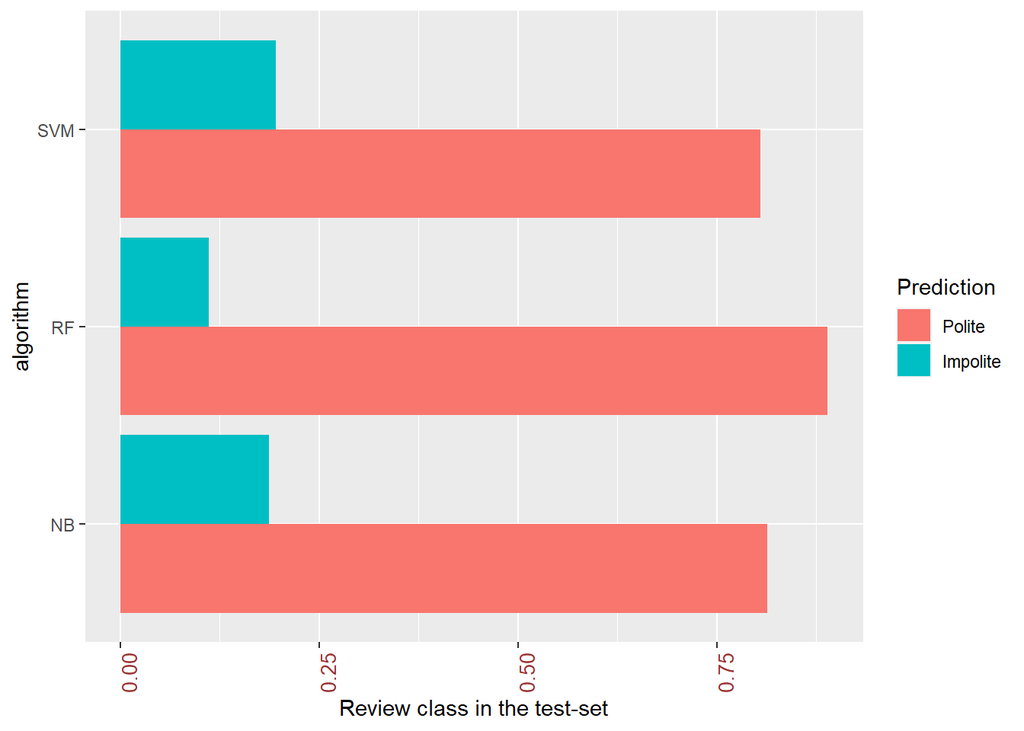

```r
#3 PLOT
ggplot(df.long,aes(algorithm,value,fill=variable))+
  geom_bar(position="dodge",stat="identity") + theme(axis.text.x = element_text(color="#993333", size=10, angle=90)) + coord_flip() +
  ylab(label="Review class in the test-set") +  xlab("algorithm") + scale_fill_discrete(name = "Prediction", labels = c("Polite", "Impolite"))
```

*EXTRA: PREDICT SENTIMENT VARIABLE*

The extra part, having little time available, I decided to do it using only one model: the random forest. first I decided to use the as.factor function in the model creation.

```r
# Random Forest

set.seed(123)
system.time(RFs <- ranger(y= as.factor(Dfm_train@docvars$Sentiment), x=train, keep.inbag=TRUE))
```

```
##    utente   sistema trascorso
##      2.32      0.02      0.81
```

```r
RFs
```

```
## Ranger result
##
## Call:
##  ranger(y = as.factor(Dfm_train@docvars$Sentiment), x = train,      keep.inbag = TRUE)
##
## Type:                             Classification
## Number of trees:                  500
## Sample size:                      360
## Number of independent variables:  405
## Mtry:                             20
## Target node size:                 1
## Variable importance mode:         none
## Splitrule:                        gini
## OOB prediction error:             44.17 %
```

```r
# see how often observations/texts are in-bag in each tree. Let's see the first (of 500) tree:
head(RFs$inbag.counts[1], 25)
```

```
## [[1]]
##   [1] 1 1 0 2 0 0 3 0 0 2 3 0 5 0 2 0 0 0 2 0 0 1 2 0 0 1 2 1 0 1 1 1 1 1 0 1 1
##  [38] 1 0 0 0 2 3 1 1 2 0 1 0 0 1 1 2 2 1 2 1 0 1 2 1 0 1 0 0 0 2 2 1 1 2 2 3 0
##  [75] 3 0 1 4 0 1 1 0 1 0 1 0 1 2 0 1 0 2 1 2 0 1 2 1 2 0 2 1 0 1 3 1 0 0 1 0 1
## [112] 1 1 0 2 1 2 0 1 1 0 1 1 1 2 2 2 1 2 2 0 0 0 1 1 1 1 1 3 2 0 1 1 1 1 3 1 1
## [149] 3 0 0 1 1 0 3 0 0 2 2 1 2 1 2 1 1 0 1 2 0 0 0 0 0 1 0 0 0 0 2 1 0 0 0 2 0
## [186] 1 1 1 2 1 0 3 1 4 0 1 1 0 1 1 1 2 0 0 2 0 2 2 3 1 0 0 1 2 2 0 0 2 2 2 1 0
## [223] 1 0 3 2 3 0 1 0 0 2 1 2 0 0 2 1 2 0 0 1 1 1 1 1 0 1 0 0 1 0 0 1 1 1 2 2 3
## [260] 1 1 1 1 0 2 2 0 1 0 2 1 1 0 0 1 1 1 0 1 1 1 0 1 0 2 0 0 0 1 0 1 2 2 1 1 0
## [297] 0 1 3 0 1 2 2 1 3 2 2 1 0 0 1 0 1 0 0 2 1 2 2 0 2 0 1 1 0 0 1 2 2 0 1 1 3
## [334] 1 1 2 1 0 0 0 2 2 1 2 0 3 1 0 0 1 0 1 1 1 0 2 0 2 2 1
```

```r
RFs
```

```
## Ranger result
##
## Call:
##  ranger(y = as.factor(Dfm_train@docvars$Sentiment), x = train,      keep.inbag = TRUE)
##
## Type:                             Classification
## Number of trees:                  500
## Sample size:                      360
## Number of independent variables:  405
## Mtry:                             20
## Target node size:                 1
## Variable importance mode:         none
## Splitrule:                        gini
## OOB prediction error:             44.17 %
```

```r
RFs$prediction.error
```

```
## [1] 0.4416667
```

```r
1-RFs$prediction.error
```

```
## [1] 0.5583333
```

in this case the predicted error is about 44%, a little high. I repeated the loop to see which number of trees gave the least possible error, but at this point I decided to increase the number up to a maximum of 1001:

```r
nt <- seq(1, 1001, 10)

oob_mse <- vector("numeric", length(nt))

for(i in 1:length(nt)){
  set.seed(123)
  rr2 <- ranger(y= as.factor(Dfm_train@docvars$Sentiment), x=train,  num.threads=4, num.trees = nt[i], write.forest = FALSE)
  oob_mse[i] <- rr2$prediction.error
}
```

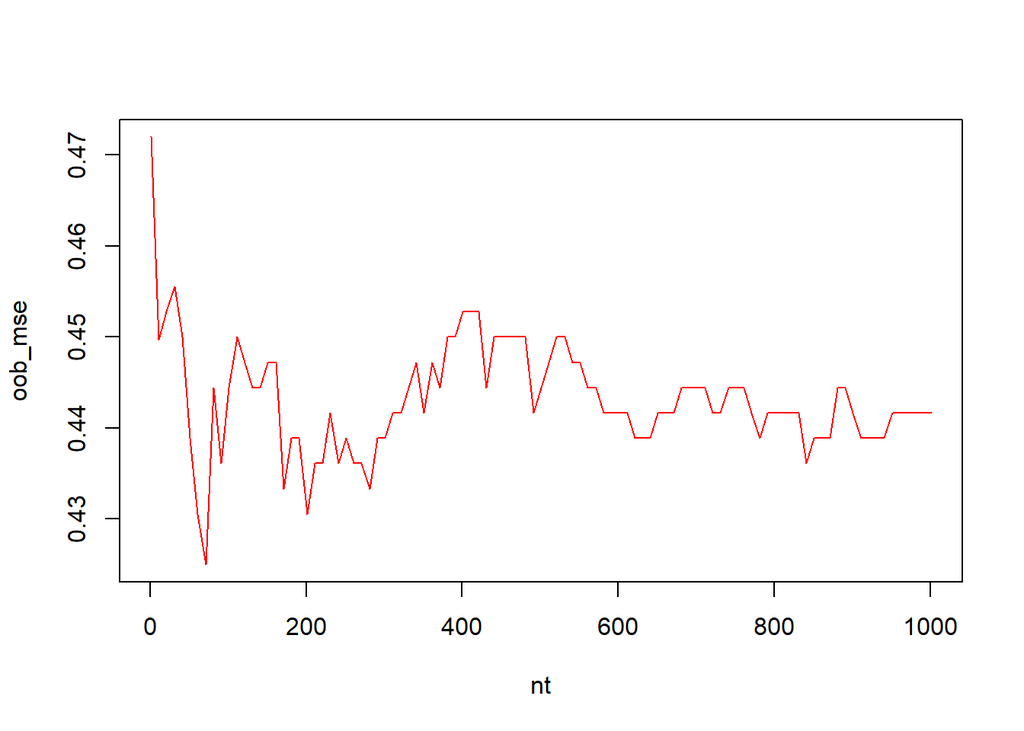

```r
plot(x = nt, y = oob_mse, col = "red", type = "l")
```

it seems that the optimal number of trees is 71: so I set num.trees = 71 in the ranger function.

```r
#71 num. of trees
set.seed(123)
system.time(rf2s <- ranger(y= as.factor(Dfm_train@docvars$Sentiment), num.trees = 71, x=train, keep.inbag=TRUE))
```

```
##    utente   sistema trascorso
##      0.51      0.00      0.11
```

```r
rf2s
```

```
## Ranger result
##
## Call:
##  ranger(y = as.factor(Dfm_train@docvars$Sentiment), num.trees = 71,      x = train, keep.inbag = TRUE)
##
## Type:                             Classification
## Number of trees:                  71
## Sample size:                      360
## Number of independent variables:  405
## Mtry:                             20
## Target node size:                 1
## Variable importance mode:         none
## Splitrule:                        gini
## OOB prediction error:             42.50 %
```

Now the OOB prediction error is pretty lower: 42.50 %

```r
set.seed(123)
system.time(RFIs <- ranger(y= as.factor(Dfm_train@docvars$Sentiment), x=train, num.trees = 71, importance="permutation", scale.permutation.importance = TRUE))
```

```
##    utente   sistema trascorso
##      2.83      0.02      0.59
```

I then set importance = permutation in the function to see which were the most important words

```r
# 10 most important words
head(sort(RFIs$variable.importance , decreasing=TRUE), 10)
```

```
##      fuck       tri      twat     thank    bloodi    favour       war    believ
## 13.800784  5.632674  4.365330  4.174522  3.893694  3.873894  3.768966  3.483442
##        ok    someth
##  3.477724  3.436961
```

Turns out the most important word (as in the random forest before) is “fuck” with a score of about 13% (then “tri” twat” and “thank”). So, it’s the most important word if we’re trying to predict our DV in the OOB data.

```r
set.seed(123)
system.time(predicted_rfs <- predict(rf2s, test))
```

```
##    utente   sistema trascorso
##      0.01      0.01      0.03
```

```r
str(predicted_rfs )
```

```
## List of 5
##  $ predictions              : Factor w/ 3 levels "negative","neutral",..: 2 2 2 2 1 2 3 2 2 2 ...
##  $ num.trees                : num 71
##  $ num.independent.variables: num 405
##  $ num.samples              : int 2
##  $ treetype                 : chr "Classification"
##  - attr(*, "class")= chr "ranger.prediction"
```

```r
table(predicted_rfs$predictions )
```

```
##
## negative  neutral positive
##       76      248       19
```

```r
prop.table(table(predicted_rfs$predictions ))
```

```
##
##   negative    neutral   positive
## 0.22157434 0.72303207 0.05539359
```

In the table above are shown in absolute values and proportionally the texts belonging to each category: 73% is neutral, 22% is negative while only 5% is positive.

```r
set.seed(123)
system.time(RF2s <- ranger(y= as.factor(Dfm_train@docvars$Sentiment), x=train,  probability=TRUE))
```

```
##    utente   sistema trascorso
##      3.56      0.00      0.64
```

```r
set.seed(123)
system.time(predicted_rf2s <- predict(RF2s, test))
```

```
##    utente   sistema trascorso
##      0.30      0.02      0.11
```

```r
head(predicted_rf2s$predictions )
```

```
##       negative   neutral   positive
## [1,] 0.1510738 0.7718068 0.07711943
## [2,] 0.2236290 0.7623180 0.01405306
## [3,] 0.1443660 0.7294953 0.12613872
## [4,] 0.2605049 0.6289990 0.11049613
## [5,] 0.4688541 0.5081334 0.02301249
## [6,] 0.1007978 0.8830167 0.01618546
```

Lastly, I set the argument “predict.all=TRUE,” in order to access the predictions made by each tree for specific documents in the test set.

```r
set.seed(123)
system.time(predicted_rfALLs <- predict(rf2s, test, predict.all=TRUE))
```

```
##    utente   sistema trascorso
##      0.01      0.00      0.02
```

```r
# let's see the prediction of the 71 trees for the first text in the test-set
predicted_rfALLs$predictions[1,]
```

```
##  [1] 2 2 2 2 2 2 2 2 2 2 2 2 2 2 2 2 2 2 2 2 2 2 2 2 2 2 2 2 2 2 2 2 2 2 2 2 2 2
## [39] 2 2 2 2 2 2 2 2 2 2 2 2 2 2 2 2 2 2 2 2 2 2 2 2 2 2 2 2 2 2 2 2 2
```

for all the trees, this documents belong to the neutral category

```r
head(predicted_rfs$predictions )
```

```
## [1] neutral  neutral  neutral  neutral  negative neutral
## Levels: negative neutral positive
```

Lastly i displayed the head of the predictions: among the first 6 documents, only the number 5 is negative. All the others are neutral.

End.